# ANCOM vs. SIMPER vs. CORNCOB

# The difference between ANCOM and SIMPER and CornCob

- ANCOM - which asvs are significantly different
- SIMPER - compares 2 groups and determines which taxa contributes to differences
- CornCob - an individual taxon regression model that uses abundance tables and sample data to model differential abundances and addresses many statistical challenges in analyzing microbial data

Load in the libraries and source code files you will need:

```r
library(nlme)
library(dplyr)
library(ggplot2)
library(compositions)
library(phyloseq)
library(vegan)
library(tidyverse)
#needed to run ANCOM
source("ANCOM_funcs.R")
```

[output not shown]

# ANCOM: Analysis of Composition of Microbes

Mandal S., Van Treuren W., White R. A., Eggesb M., Knight R., Peddada S. D. (2015). Analysis of composition of microbiomes: a novel method for studying microbial composition. Microb. Ecol. Health Dis. 26, 1–7. 10.3402/mehd.v26.27663; https://www.ncbi.nlm.nih.gov/pmc/articles/PMC4450248/

## Purpose

Used for comparing the composition of microbiomes in two or more populations. ANCOM makes no distributional assumptions and can be used in a linear model framework to adjust for covariates. It also scales well for large datasets.

Used to analyze differential abundances of bacterial taxa across factors in a group. For example, finding differential abundances of taxa within different coral species or within different progression time points. It returns the W-statistic, the higher the W, the more taxa an ASV is significantly different against.

See Rosales et al., 2020 for a good example https://www.frontiersin.org/articles/10.3389/fmicb.2020.00681/full?report=r

## Code

### Source

ANCOM v2.1: https://github.com/FrederickHuangLin/ANCOM

### Implementation

Make sure that you have ‘ANCOM_funcs.r’ saved in the same file as the R notebook/markdown you are working in.

#### Get your data in

We’re using the ACER microbiome dataset as an example.

```r
ps
```

```
phyloseq-class experiment-level object
otu_table()   OTU Table:         [ 234 taxa and 64 samples ]
sample_data() Sample Data:       [ 64 samples by 13 sample variables ]
tax_table()   Taxonomy Table:    [ 234 taxa by 7 taxonomic ranks ]
```

#### Pre-processing

feature_table_pre_process(feature_table, meta_data, sample_var, group_var = NULL, out_cut = 0.05, zero_cut = 0.90, lib_cut, neg_lb)

Feature table = your otu table AND the taxa need to be in rows and the samples need to be in columns and the values need to be absolute abundances meta_data = sample data sample_var = column name of sample IDs group_var = name of the group indicator

```r
prepro
```

|  | AC1.4 | AC10.4 | AC13.22 | AC20 | AC29 | AC31.15 | AC34 | AC38 | AC4.13 | AC41.24 | AC44.3 | AC46.21 | AC47.21 | AC48 | AC5.5 | AC50.18 | AC51 | AC54 | AC55 | AC56 | AC57.9 | AC58.3 | AC6 | AC62.13 | AC63 | AC70 | AC75 | AC76 | AC77 | … |
| --- | --- | --- | --- | --- | --- | --- | --- | --- | --- | --- | --- | --- | --- | --- | --- | --- | --- | --- | --- | --- | --- | --- | --- | --- | --- | --- | --- | --- | --- | --- |
| ASV_1 | 25842 | 26080 | 24992 | 24895 | 25782 | 25977 | 26001 | 25204 | 25085 | 24997 | 24531 | 25932 | 24594 | 26013 | 25861 | 25147 | 26060 | 25933 | 25866 | 26192 | 23696 | 25766 | 26095 | 23826 | 24784 | 25387 | 24748 | 26211 | 25725 | … |
| ASV_2 | 18 | 9 | 14 | 12 | 22 | 19 | 25 | 13 | 20 | 11 | 22 | 16 | 32 | 23 | 31 | 14 | 22 | 18 | 33 | 24 | 24 | 16 | 11 | 40 | 23 | 25 | 16 | 34 | 18 | … |
| ASV_3 | 143 | 60 | 622 | 1185 | 276 | 90 | 63 | 777 | 343 | 833 | 281 | 64 | 21 | 85 | 84 | 760 | 83 | 115 | 78 | 22 | 746 | 294 | 16 | 155 | 183 | 668 | 257 | 103 | 472 | … |
| ASV_4 | 44 | 3 | 0 | 5 | 7 | 0 | 1 | 12 | 0 | 1 | 1191 | 0 | 1508 | 75 | 5 | 4 | 0 | 6 | 156 | 3 | 7 | 6 | 0 | 2048 | 1133 | 0 | 0 | 0 | 0 | … |
| ASV_5 | 107 | 114 | 96 | 124 | 119 | 122 | 107 | 113 | 90 | 89 | 111 | 117 | 95 | 94 | 112 | 112 | 117 | 118 | 122 | 109 | 111 | 97 | 115 | 99 | 94 | 84 | 114 | 0 | 100 | … |
| ASV_6 | 14 | 0 | 2 | 17 | 1 | 3 | 4 | 10 | 4 | 11 | 10 | 21 | 29 | 11 | 16 | 7 | 2 | 10 | 17 | 6 | 9 | 1 | 5 | 56 | 2 | 116 | 4 | 12 | 11 | … |
| ASV_7 | 3 | 2 | 421 | 1 | 0 | 3 | 2 | 2 | 54 | 5 | 1 | 2 | 1 | 0 | 3 | 74 | 1 | 1 | 2 | 4 | 2 | 0 | 0 | 1 | 0 | 0 | 0 | 0 | 0 | … |
| ASV_8 | 14 | 15 | 10 | 14 | 14 | 16 | 10 | 16 | 16 | 12 | 8 | 16 | 12 | 12 | 14 | 9 | 13 | 11 | 30 | 10 | 11 | 10 | 13 | 11 | 19 | 18 | 27 | 18 | 15 | … |
| ASV_9 | 2 | 1 | 0 | 0 | 0 | 0 | 0 | 9 | 0 | 3 | 2 | 0 | 1 | 0 | 1 | 0 | 0 | 12 | 1 | 0 | 1 | 3 | 0 | 0 | 0 | 0 | 0 | 0 | 0 | … |
| ASV_10 | 6 | 8 | 12 | 40 | 65 | 8 | 0 | 10 | 219 | 59 | 27 | 17 | 0 | 18 | 0 | 97 | 9 | 2 | 1 | 0 | 42 | 32 | 0 | 1 | 24 | 7 | 1 | 5 | 2 | … |

[output cut: 53 more lines]

|  | Sample.ID | Orig_geno_ID | X2020_Mote_ID | Genotype | Outlier | sampling_date | Species | Lat | Long | Region | collection_date | Baums_MSAT_clonal_ID | Proposed_pheno |
| --- | --- | --- | --- | --- | --- | --- | --- | --- | --- | --- | --- | --- | --- |
| AC1.4 | AC1.4 | 1 | M-L-1 | 1.4 | No | 11/12/19 | cervicornis | 24.56937 | -81.33028 | Lower Keys | 2/23/08 | C1153 (AF) | Susceptible |
| AC10.4 | AC10.4 | 10 | M-L-10 | 10.4 | No | 11/12/19 | cervicornis | 24.61515 | -81.37917 | Lower Keys | 2/23/08 | C1083 (DG) | Susceptible |
| AC13.22 | AC13.22 | 13 | M-L-13 | 13.22 | No | 11/12/19 | cervicornis | 24.59592 | -81.37162 | Lower Keys | 12/1/09 | C1365 | Susceptible |
| AC20 | AC20 | 20 | M-L-20 | 20 | No | 12/13/19 | cervicornis | 24.62167 | -81.36313 | Lower Keys | 12/15/09 | C1191 | Susceptible |
| AC29 | AC29 | 29 | M-L-29 | 29 | No | 12/13/19 | cervicornis | 24.52172 | -81.57675 | Lower Keys | 5/28/10 | C1377 | NA |
| AC31.15 | AC31.15 | 31 | M-L-31 | 31.15 | No | 11/12/19 | cervicornis | 24.54770 | -81.45696 | Lower Keys | 3/18/10 | C1369 | Susceptible |
| AC34 | AC34 | 34 | M-L-34 | 34 | No | 12/13/19 | cervicornis | 24.53865 | -81.44358 | Lower Keys | 3/26/10 | C1363 | Susceptible |
| AC38 | AC38 | 38 | M-L-38 | 38 | No | 12/13/19 | cervicornis | 24.56306 | -81.40063 | Lower Keys | 4/5/10 | C1378 | NA |
| AC4.13 | AC4.13 | 4 | M-L-4 | 4.13 | No | 11/12/19 | cervicornis | 24.56935 | -81.38168 | Lower Keys | 2/23/08 | C1156 (CW) | Susceptible |
| AC41.24 | AC41.24 | 41 | M-L-41 | 41.24 | No | 11/12/19 | cervicornis | 24.55320 | -81.43758 | Lower Keys | 5/10/10 | C1374 | Susceptible |

[output cut: 54 more lines]

#### Running the ANCOM

ANCOM(feature_table, meta_data, struc_zero, main_var, p_adj_method, alpha, adj_formula, rand_formula, …)

main_var = the name of the main variable of interest –> name of column for groups you are comparing

```r
main_var = "Region"
p_adj_method = "BH"
alpha = 0.05
adj_formula = NULL
rand_formula = NULL
t_start = Sys.time()
res = ANCOM(feature_table, meta_data, struc_zero, main_var, p_adj_method, alpha, adj_formula, rand_formula)
t_end = Sys.time()
t_run = t_end - t_start
t_run
```

```
Time difference of 2.648426 secs
```

The ANCOM returns the w statistic for each taxa and subsequent columns which are logical indicators of whether an OTU or taxon is differentially abundant under a series of cutoffs (0.9, 0.8, 0.7 and 0.6). detected_0.7 is commonly used.

|  | taxa_id | W | detected_0.9 | detected_0.8 | detected_0.7 | detected_0.6 |
| --- | --- | --- | --- | --- | --- | --- |
| 2 | ASV_2 | 62 | TRUE | TRUE | TRUE | TRUE |
| 8 | ASV_8 | 60 | TRUE | TRUE | TRUE | TRUE |
| 28 | ASV_30 | 48 | FALSE | FALSE | TRUE | TRUE |

|  | dif.abund.tax$W | Kingdom | Phylum | Class | Order | Family | Genus | Species |
| --- | --- | --- | --- | --- | --- | --- | --- | --- |
| ASV_2 | 62 | Bacteria | Spirochaetes | Spirochaetia | Spirochaetales | Spirochaetaceae | Spirochaeta_2 | Genus_Spirochaeta_2 |
| ASV_8 | 60 | Bacteria | Spirochaetes | Spirochaetia | Spirochaetales | Spirochaetaceae | Spirochaeta_2 | Genus_Spirochaeta_2 |
| ASV_30 | 48 | Bacteria | Spirochaetes | Spirochaetia | Spirochaetales | Spirochaetaceae | Spirochaeta_2 | Genus_Spirochaeta_2 |

So here, there are 3 differentially abundant ASVs all are Spirochaetales, Genus Spirochaeta_2.

#### How to subset your phyloseq object by the asvs determined to be differentially abundant by ANCOM

```r
ps_difabund
```

```
phyloseq-class experiment-level object
otu_table()   OTU Table:         [ 3 taxa and 64 samples ]
sample_data() Sample Data:       [ 64 samples by 13 sample variables ]
tax_table()   Taxonomy Table:    [ 3 taxa by 7 taxonomic ranks ]
```

# SIMPER: similiarity percentage analysis

Clarke, K. R. (1993). Non‐parametric multivariate analyses of changes in community structure. Australian journal of ecology, 18(1), 117-143.

https://onlinelibrary.wiley.com/doi/10.1111/j.1442-9993.1993.tb00438.x

## Purpose

The simper functions performs pairwise comparisons of groups of sampling units and finds the contribution of each species to the average between-group Bray-Curtis dissimilarity. Although the method is called simper, it really studied dissimilarities instead of similarities (Clarke 1993).

Used to identify which taxa are most important at driving the differences among the groups.

Used to identify the main contributing taxa for similiarity within each of the groups or differences between the groups.

## Code

simper is a function in the vegan package.

The function displays most important species for each pair of groups. These species contribute at least to 70 % of the differences between groups. data frames also include the cumulative contributions and are ordered by species contribution.The method gives the contribution of each species to overall dissimilarities, but these are caused by variation in species abundances, and only partly by differences among groups. … *So don’t use SIMPER because it is biased by highly abundant species.*

```r
df<-(data.frame(otu_table(ps)))
sampledf<-data.frame(sample_data(ps))
simp<-simper(df,sampledf$Region)
str(simp)
```

```
List of 3
 $ Lower Keys_Upper Keys :List of 10
  ..$ species: chr [1:234] "ASV_1" "ASV_2" "ASV_3" "ASV_4" ...
  ..$ average: num [1:234] 0.041664 0.045057 0.004866 0.004844 0.000623 ...
  ..$ overall: num 0.107
  ..$ sd     : num [1:234] 0.030547 0.034109 0.005122 0.012433 0.000684 ...
  ..$ ratio  : num [1:234] 1.364 1.321 0.95 0.39 0.912 ...
  ..$ ava    : Named num [1:234] 25345 118 263 255 104 ...
  .. ..- attr(*, "names")= chr [1:234] "ASV_1" "ASV_2" "ASV_3" "ASV_4" ...
  ..$ avb    : Named num [1:234] 23490.77 2451.38 165.15 3.46 90.54 ...
  .. ..- attr(*, "names")= chr [1:234] "ASV_1" "ASV_2" "ASV_3" "ASV_4" ...
  ..$ ord    : int [1:234] 2 1 3 4 8 5 16 7 44 11 ...
  ..$ cusum  : num [1:234] 0.422 0.812 0.857 0.903 0.913 ...
  ..$ p      : NULL
 $ Lower Keys_Middle Keys:List of 10
  ..$ species: chr [1:234] "ASV_1" "ASV_2" "ASV_3" "ASV_4" ...
  ..$ average: num [1:234] 0.028927 0.030022 0.004401 0.006795 0.000424 ...
  ..$ overall: num 0.0795
  ..$ sd     : num [1:234] 0.020788 0.024771 0.004869 0.014351 0.000545 ...
  ..$ ratio  : num [1:234] 1.392 1.212 0.904 0.473 0.778 ...
  ..$ ava    : Named num [1:234] 25345 118 263 255 104 ...
  .. ..- attr(*, "names")= chr [1:234] "ASV_1" "ASV_2" "ASV_3" "ASV_4" ...
  ..$ avb    : Named num [1:234] 24279 1642 114 136 103 ...
  .. ..- attr(*, "names")= chr [1:234] "ASV_1" "ASV_2" "ASV_3" "ASV_4" ...
  ..$ ord    : int [1:234] 2 1 4 3 8 16 11 5 10 12 ...
  ..$ cusum  : num [1:234] 0.377 0.741 0.827 0.882 0.894 ...
  ..$ p      : NULL
 $ Upper Keys_Middle Keys:List of 10
  ..$ species: chr [1:234] "ASV_1" "ASV_2" "ASV_3" "ASV_4" ...
  ..$ average: num [1:234] 0.036489 0.036009 0.003153 0.002613 0.000685 ...
  ..$ overall: num 0.0849
  ..$ sd     : num [1:234] 0.02728 0.027807 0.003516 0.009561 0.000739 ...
  ..$ ratio  : num [1:234] 1.338 1.295 0.897 0.273 0.927 ...
  ..$ ava    : Named num [1:234] 23490.77 2451.38 165.15 3.46 90.54 ...
  .. ..- attr(*, "names")= chr [1:234] "ASV_1" "ASV_2" "ASV_3" "ASV_4" ...
  ..$ avb    : Named num [1:234] 24279 1642 114 136 103 ...
  .. ..- attr(*, "names")= chr [1:234] "ASV_1" "ASV_2" "ASV_3" "ASV_4" ...
  ..$ ord    : int [1:234] 1 2 3 4 8 5 44 11 24 16 ...
  ..$ cusum  : num [1:234] 0.43 0.854 0.891 0.922 0.931 ...
  ..$ p      : NULL
```

[output cut: 16 more lines]

```
  .. ..$ plots.name: chr "NULL"
  .. ..$ call      : language Plots()
  .. ..- attr(*, "class")= chr "Plots"
  ..$ blocks     : NULL
  ..$ nperm      : num 0
  ..$ complete   : logi FALSE
  ..$ maxperm    : num 9999
  ..$ minperm    : num 5040
  ..$ all.perms  : NULL
  ..$ make       : logi TRUE
  ..$ observed   : logi FALSE
  ..$ blocks.name: chr "NULL"
  ..$ call       : language how(nperm = 0)
  ..- attr(*, "class")= chr "how"
 - attr(*, "class")= chr "simper"
```

```r
summary(simp,ordered=TRUE)
```

```
Contrast: Lower Keys_Upper Keys
```

|  | average | sd | ratio | ava | avb | cumsum |
| --- | --- | --- | --- | --- | --- | --- |
| ASV_2 | 4.505737e-02 | 3.410937e-02 | 1.3209676 | 1.183611e+02 | 2.451385e+03 | 0.4218447 |
| ASV_1 | 4.166382e-02 | 3.054745e-02 | 1.3639052 | 2.534508e+04 | 2.349077e+04 | 0.8119176 |
| ASV_3 | 4.865504e-03 | 5.122288e-03 | 0.9498693 | 2.630000e+02 | 1.651538e+02 | 0.8574703 |
| ASV_4 | 4.844263e-03 | 1.243261e-02 | 0.3896418 | 2.553333e+02 | 3.461538e+00 | 0.9028242 |
| ASV_8 | 1.069394e-03 | 7.055912e-04 | 1.5156004 | 1.925000e+01 | 7.269231e+01 | 0.9128363 |
| ASV_5 | 6.232433e-04 | 6.836907e-04 | 0.9115866 | 1.040556e+02 | 9.053846e+01 | 0.9186713 |
| ASV_16 | 5.549035e-04 | 2.116202e-03 | 0.2622167 | 2.402778e+01 | 8.000000e+00 | 0.9238665 |
| ASV_7 | 4.655212e-04 | 1.289401e-03 | 0.3610370 | 1.630556e+01 | 1.100000e+01 | 0.9282249 |
| ASV_48 | 4.204779e-04 | 1.458137e-03 | 0.2883665 | 0.000000e+00 | 2.230769e+01 | 0.9321616 |
| ASV_11 | 4.075422e-04 | 3.352447e-04 | 1.2156558 | 2.450000e+01 | 2.700000e+01 | 0.9359772 |

[output cut: 224 more lines]

```
Contrast: Lower Keys_Middle Keys
```

|  | average | sd | ratio | ava | avb | cumsum |
| --- | --- | --- | --- | --- | --- | --- |
| ASV_2 | 3.002185e-02 | 2.477127e-02 | 1.2119625 | 1.183611e+02 | 1.641533e+03 | 0.3774234 |
| ASV_1 | 2.892737e-02 | 2.078757e-02 | 1.3915704 | 2.534508e+04 | 2.427920e+04 | 0.7410874 |
| ASV_4 | 6.794633e-03 | 1.435086e-02 | 0.4734651 | 2.553333e+02 | 1.356667e+02 | 0.8265070 |
| ASV_3 | 4.401365e-03 | 4.869388e-03 | 0.9038848 | 2.630000e+02 | 1.139333e+02 | 0.8818393 |
| ASV_8 | 9.843863e-04 | 7.047495e-04 | 1.3967889 | 1.925000e+01 | 6.673333e+01 | 0.8942146 |
| ASV_16 | 5.404338e-04 | 2.115746e-03 | 0.2554341 | 2.402778e+01 | 7.266667e+00 | 0.9010088 |
| ASV_11 | 4.350102e-04 | 3.539046e-04 | 1.2291737 | 2.450000e+01 | 1.806667e+01 | 0.9064775 |
| ASV_5 | 4.244358e-04 | 5.453332e-04 | 0.7783055 | 1.040556e+02 | 1.030000e+02 | 0.9118134 |
| ASV_10 | 4.006104e-04 | 7.374302e-04 | 0.5432519 | 2.113889e+01 | 2.800000e+00 | 0.9168497 |
| ASV_12 | 3.970990e-04 | 3.838271e-04 | 1.0345778 | 2.783333e+01 | 9.866667e+00 | 0.9218419 |

[output cut: 224 more lines]

```
Contrast: Upper Keys_Middle Keys
```

|  | average | sd | ratio | ava | avb | cumsum |
| --- | --- | --- | --- | --- | --- | --- |
| ASV_1 | 3.648926e-02 | 2.728002e-02 | 1.3375819 | 2.349077e+04 | 2.427920e+04 | 0.4298043 |
| ASV_2 | 3.600858e-02 | 2.780670e-02 | 1.2949603 | 2.451385e+03 | 1.641533e+03 | 0.8539466 |
| ASV_3 | 3.153375e-03 | 3.516373e-03 | 0.8967692 | 1.651538e+02 | 1.139333e+02 | 0.8910900 |
| ASV_4 | 2.613195e-03 | 9.560849e-03 | 0.2733224 | 3.461538e+00 | 1.356667e+02 | 0.9218706 |
| ASV_8 | 8.125688e-04 | 6.225537e-04 | 1.3052188 | 7.269231e+01 | 6.673333e+01 | 0.9314418 |
| ASV_5 | 6.845944e-04 | 7.386155e-04 | 0.9268617 | 9.053846e+01 | 1.030000e+02 | 0.9395056 |
| ASV_48 | 5.032822e-04 | 1.454789e-03 | 0.3459485 | 2.230769e+01 | 5.200000e+00 | 0.9454337 |
| ASV_11 | 4.346972e-04 | 3.362843e-04 | 1.2926479 | 2.700000e+01 | 1.806667e+01 | 0.9505540 |
| ASV_24 | 2.513555e-04 | 2.860549e-04 | 0.8786968 | 9.461538e+00 | 8.000000e+00 | 0.9535147 |
| ASV_16 | 2.302978e-04 | 2.995911e-04 | 0.7687071 | 8.000000e+00 | 7.266667e+00 | 0.9562274 |

[output cut: 224 more lines]

```
Permutation: free
Number of permutations: 0
```

Can use Kruskal Wallis to test significance

```r
kruskal.test(df$ASV_1~sampledf$Region)
```

```
    Kruskal-Wallis rank sum test

data:  df$ASV_1 by sampledf$Region
Kruskal-Wallis chi-squared = 12.302, df = 2, p-value = 0.002132
```

```r
kruskal.test(df$ASV_2~sampledf$Region)
```

```
    Kruskal-Wallis rank sum test

data:  df$ASV_2 by sampledf$Region
Kruskal-Wallis chi-squared = 21.278, df = 2, p-value = 2.396e-05
```

#### Now, what about ANOSIM?

Analysis of similarities (ANOSIM) provides a way to test statistically whether there is a significant difference between two or more groups of sampling units. … Ok, so it’s basically a SIMPER but assigns a p value to obtain statistical significance and doesn’t tell you what ASVs are different.

```r
anosim(df,sampledf$Region)
```

```
Call:
anosim(x = df, grouping = sampledf$Region)
Dissimilarity: bray

ANOSIM statistic R: 0.4139
      Significance: 0.001

Permutation: free
Number of permutations: 999
```

### CornCob

From the corncob intro: Effectively modeling microbial relative abundance poses a number of statistical challenges, including: - different sequencing depth, - excessive zeros from unobserved taxa, - high variability of empirical relative abundances (overdispersion), - within-taxon correlation, - hypothesis testing with categorical and continuous covariates.

Corncob is an individual taxon regression model that uses abundance tables and sample data. corncob is able to model differential abundance and differential variability, and addresses each of the challenges presented above.

```r
library(corncob)
help(package = "corncob", help_type = "html")
utils::browseVignettes(package = "corncob")
```

#### Fit a model to look at one ASV

Use the bbdml function: Maximum likelihood for the beta-binomial distribution Since we aren’t looking at any covariates, we just use the formula response ~ 1

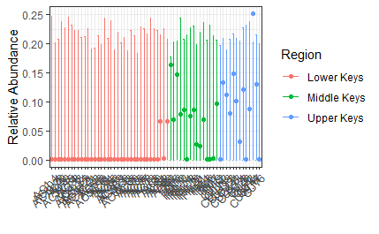

```r
corn<-bbdml(formula=ASV_2~1, #model to be fitted to the abundance
            phi.formula = ~1, #model to be fitted to the dispersion
            data=ps) #phyloseq obeject
plot(corn, #model output
     b=50, #number of bootstrap simulations to be used to approximate the prediction intervals, rec. 1000
     total=FALSE, #makes plot on the counts scale with 95% prediction intervals, default is relative abundance
     color="Region") #color the points by region of sample
```

The bars represent the 95% prediction intervals for the observed relative abundance by sample. We can observe on this plot that it might be of interest to distinguish between the three groups with covariates. The average empirical relative abundance for the samples from the lower keys are lowerthan the samples from the middle and upper keys.

### Add a covariate

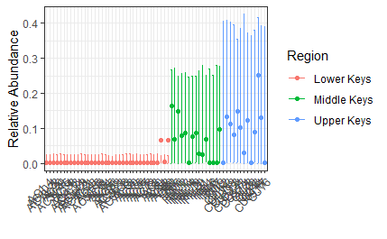

```r
corn_da<-bbdml(formula=ASV_2~Region, #now lets look at ASV_2 as it covaries with region
            phi.formula = ~Region, #model to be fitted to the dispersion
            data=ps) #phyloseq obeject
plot(corn_da, #model output
     b=50, #number of bootstrap simulations to be used to approximate the prediction intervals, rec. 1000
     #total=TRUE, #makes plot on the counts scale with 95% prediction intervals, default is relative abundance
     color="Region") #color the points by region of sample
```

Visually, the co-variate (region) provides a much better fit to the data.

#### Interpreting the model output

```r
summary(corn_da)
```

```
Call:
bbdml(formula = ASV_2 ~ Region, phi.formula = ~Region, data = ps)


Coefficients associated with abundance:
                  Estimate Std. Error t value Pr(>|t|)
(Intercept)        -5.3874     0.2584 -20.850  < 2e-16 ***
RegionMiddle Keys   2.6381     0.4168   6.330 3.87e-08 ***
RegionUpper Keys    3.0457     0.4449   6.846 5.31e-09 ***
---
Signif. codes:  0 ‘***’ 0.001 ‘**’ 0.01 ‘*’ 0.05 ‘.’ 0.1 ‘ ’ 1


Coefficients associated with dispersion:
                  Estimate Std. Error t value Pr(>|t|)
(Intercept)        -4.5121     0.3205 -14.078  < 2e-16 ***
RegionMiddle Keys   2.2118     0.5318   4.159 0.000107 ***
RegionUpper Keys    2.6816     0.5508   4.869 9.01e-06 ***
---
Signif. codes:  0 ‘***’ 0.001 ‘**’ 0.01 ‘*’ 0.05 ‘.’ 0.1 ‘ ’ 1


Log-likelihood: -431.78
```

So since we have 3 levels of Region, the test is comparing the middle and upper to the lower keys.

From the coefficients associated with abundance: Middle keys have significantly more ASV 2 than lower, know this because estimate is positive and P<0.05 Upper keys have significantly more ASV2 than lower as well

#### Analysis for multiple taxa

```r
set.seed(1)
da_analysis<-differentialTest(formula = ~Region,
                              phi.formula = ~Region,
                              formula_null = ~1,
                              phi.formula_null = ~1,
                              test="Wald",
                              boot=FALSE,
                              data=ps,
                              fdr_cutoff = 0.05)
```

```r
da_analysis
```

```
Object of class differentialTest

$p: p-values
$p_fdr: FDR-adjusted p-values
$significant_taxa: taxa names of the statistically significant taxa
$significant_models: model summaries of the statistically significant taxa
$all_models: all model summaries
$restrictions_DA: covariates tested for differential abundance
$restrictions_DV: covariates tested for differential variability
$discriminant_taxa_DA: taxa for which at least one covariate associated with the abundance was perfectly discriminant
$discriminant_taxa_DV: taxa for which at least one covariate associated with the dispersion was perfectly discriminant

plot( ) to see a plot of tested coefficients from significant taxa
```

```r
da_analysis$significant_taxa
```

```
[1] "ASV_1"  "ASV_2"  "ASV_5"  "ASV_8"  "ASV_10" "ASV_12" "ASV_15" "ASV_17"
```

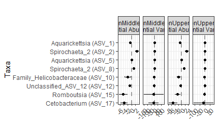

```r
plot(da_analysis,level="Genus")
```

Interpreting this graph: The effect of Region on ASV1 is negative for both the Middle and upper Keys when compared to the baseline, lower keys. THe middle and upper keys regions have a positive effect on ASV 2 compared to the lower keys.

```r
otu_to_taxonomy(da_analysis$significant_taxa,data=ps)
```

```
                                                                                                                              ASV_1
                          "Bacteria_Proteobacteria_Alphaproteobacteria_Rickettsiales_Midichloriaceae_Aquarickettsia_Aquarickettsia"
                                                                                                                              ASV_2
                              "Bacteria_Spirochaetes_Spirochaetia_Spirochaetales_Spirochaetaceae_Spirochaeta_2_Genus_Spirochaeta_2"
                                                                                                                              ASV_5
                          "Bacteria_Proteobacteria_Alphaproteobacteria_Rickettsiales_Midichloriaceae_Aquarickettsia_Aquarickettsia"
                                                                                                                              ASV_8
                              "Bacteria_Spirochaetes_Spirochaetia_Spirochaetales_Spirochaetaceae_Spirochaeta_2_Genus_Spirochaeta_2"
                                                                                                                             ASV_10
"Bacteria_Epsilonbacteraeota_Campylobacteria_Campylobacterales_Helicobacteraceae_Family_Helicobacteraceae_Family_Helicobacteraceae"
                                                                                                                             ASV_12
                                            "Bacteria_Proteobacteria___Unclassified_ASV_12_Unclassified_ASV_12_Unclassified_ASV_12"
                                                                                                                             ASV_15
                                       "Bacteria_Firmicutes_Clostridia_Clostridiales_Peptostreptococcaceae_Romboutsia_sedimentorum"
                                                                                                                             ASV_17
                           "Bacteria_Fusobacteria_Fusobacteriia_Fusobacteriales_Fusobacteriaceae_Cetobacterium_Genus_Cetobacterium"
```

### We care about upper vs lower, lower vs middle, and upper vs middle, so we can do pairwise tests

```r
da_analysis_ul$significant_taxa
```

```
[1] "ASV_1"  "ASV_2"  "ASV_5"  "ASV_8"  "ASV_10" "ASV_17" "ASV_20" "ASV_97"
```

```r
da_analysis_um$significant_taxa
```

```
character(0)
```

```r
da_analysis_ml$significant_taxa
```

```
[1] "ASV_2"  "ASV_8"  "ASV_12" "ASV_15" "ASV_17"
```

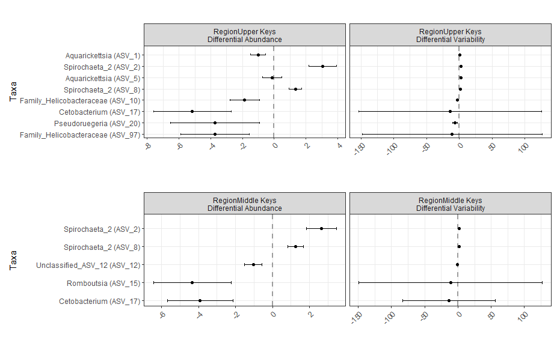

```r
#da_analysis_um$significant_taxa
p_ul<-plot(da_analysis_ul,level="Genus")
#p_um<-plot(da_analysis_um,level="Genus") #no sig taxa
p_ml<-plot(da_analysis_ml,level="Genus")
p_ul/p_ml
```

### how to get the data out of the plots

| x | xmin | xmax | taxa | variable |
| --- | --- | --- | --- | --- |
| -1.016661 | -1.4894807 | -0.5438418 | Aquarickettsia (ASV_1) | RegionUpper Keys\nDifferential Abundance |
| 1.203618 | 0.2880816 | 2.1191544 | Aquarickettsia (ASV_1) | RegionUpper Keys\nDifferential Variability |
| 3.045700 | 2.1737866 | 3.9176144 | Spirochaeta_2 (ASV_2) | RegionUpper Keys\nDifferential Abundance |
| 2.681636 | 1.6021523 | 3.7611200 | Spirochaeta_2 (ASV_2) | RegionUpper Keys\nDifferential Variability |
| -0.141610 | -0.7512106 | 0.4679906 | Aquarickettsia (ASV_5) | RegionUpper Keys\nDifferential Abundance |
| 2.267395 | 1.0732359 | 3.4615535 | Aquarickettsia (ASV_5) | RegionUpper Keys\nDifferential Variability |
| 1.330199 | 0.9370308 | 1.7233681 | Spirochaeta_2 (ASV_8) | RegionUpper Keys\nDifferential Abundance |
| 1.325011 | 0.3362203 | 2.3138020 | Spirochaeta_2 (ASV_8) | RegionUpper Keys\nDifferential Variability |
| -1.856802 | -2.8009264 | -0.9126775 | Family_Helicobacteraceae (ASV_10) | RegionUpper Keys\nDifferential Abundance |
| -2.425575 | -3.9646879 | -0.8864625 | Family_Helicobacteraceae (ASV_10) | RegionUpper Keys\nDifferential Variability |

[output cut: 6 more lines]